# exercise-10

Minsoo Joo

2025-04-04

```r
library(tidyverse)
library(skimr)
```

```r
f<-"https://raw.githubusercontent.com/difiore/ada-datasets/refs/heads/main/AVONETdataset1.csv"
d<-read_csv(f, col_names=TRUE)
d <- d %>%
  select(Species1, Family1, Order1,
         Beak.Length_Culmen, Beak.Width, Beak.Depth,
         Tarsus.Length, Wing.Length, Tail.Length, Mass,
         Habitat, Migration, Trophic.Level, Trophic.Niche,
         Min.Latitude, Max.Latitude, Centroid.Latitude,
         Primary.Lifestyle, Range.Size)

skim(d)
```

Data summary

| Name | d |
| --- | --- |
| Number of rows | 11009 |
| Number of columns | 19 |
| _______________________ |  |
| Column type frequency: |  |
| character | 7 |
| numeric | 12 |
| ________________________ |  |
| Group variables | None |

**Variable type: character**

| skim_variable | n_missing | complete_rate | min | max | empty | n_unique | whitespace |
| --- | --- | --- | --- | --- | --- | --- | --- |
| Species1 | 0 | 1.00 | 9 | 36 | 0 | 11009 | 0 |
| Family1 | 0 | 1.00 | 7 | 18 | 0 | 243 | 0 |
| Order1 | 0 | 1.00 | 10 | 19 | 0 | 36 | 0 |
| Habitat | 98 | 0.99 | 4 | 14 | 0 | 11 | 0 |
| Trophic.Level | 5 | 1.00 | 8 | 9 | 0 | 4 | 0 |
| Trophic.Niche | 10 | 1.00 | 8 | 21 | 0 | 10 | 0 |
| Primary.Lifestyle | 0 | 1.00 | 6 | 11 | 0 | 5 | 0 |

**Variable type: numeric**

| skim_variable | n_missing | complete_rate | mean | sd | p0 | p25 | p50 | p75 | p100 | hist |
| --- | --- | --- | --- | --- | --- | --- | --- | --- | --- | --- |
| Beak.Length_Culmen | 0 | 1.00 | 26.36 | 24.39 | 4.50 | 14.70 | 19.90 | 28.50 | 414.20 | ▇▁▁▁▁ |
| Beak.Width | 0 | 1.00 | 6.58 | 5.15 | 0.70 | 3.60 | 5.00 | 7.70 | 88.90 | ▇▁▁▁▁ |
| Beak.Depth | 0 | 1.00 | 8.06 | 7.59 | 1.00 | 3.80 | 5.80 | 9.40 | 110.90 | ▇▁▁▁▁ |
| Tarsus.Length | 0 | 1.00 | 28.73 | 24.84 | 2.50 | 17.40 | 22.00 | 31.30 | 481.20 | ▇▁▁▁▁ |
| Wing.Length | 0 | 1.00 | 124.78 | 93.44 | 0.10 | 66.80 | 91.50 | 145.50 | 789.90 | ▇▂▁▁▁ |
| Tail.Length | 0 | 1.00 | 86.65 | 61.08 | 0.10 | 50.20 | 68.70 | 99.90 | 812.80 | ▇▁▁▁▁ |
| Mass | 0 | 1.00 | 267.15 | 1883.03 | 1.90 | 15.00 | 35.50 | 121.00 | 111000.00 | ▇▁▁▁▁ |
| Migration | 23 | 1.00 | 1.29 | 0.62 | 1.00 | 1.00 | 1.00 | 1.00 | 3.00 | ▇▁▁▁▁ |
| Min.Latitude | 57 | 0.99 | -6.44 | 22.37 | -85.58 | -21.22 | -7.15 | 8.07 | 68.08 | ▁▃▇▃▁ |
| Max.Latitude | 57 | 0.99 | 11.51 | 23.32 | -65.12 | -3.33 | 9.00 | 22.07 | 85.01 | ▁▃▇▂▁ |
| Centroid.Latitude | 57 | 0.99 | 2.95 | 22.07 | -71.04 | -9.73 | -0.22 | 15.28 | 78.43 | ▁▃▇▂▁ |
| Range.Size | 57 | 0.99 | 2578859.38 | 7629310.06 | 0.88 | 54052.87 | 416076.61 | 2187040.21 | 136304432.20 | ▇▁▁▁▁ |

Categorical variables: Species1, Family1, Order1, Habitat, Trophic.Level, Trophic.Niche, Primary.Lifestyle

Numerical variables: all other variables

# Challenge 1

## Step 1

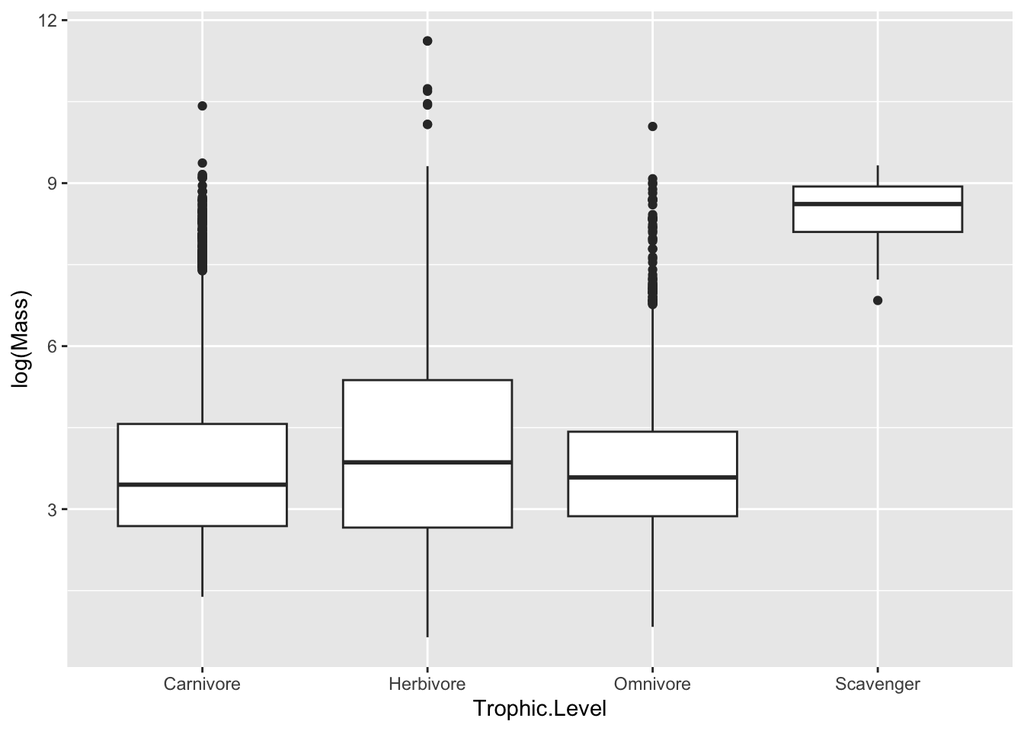

```r
d <- d %>%
  filter(!is.na(Trophic.Level), !is.na(Migration))
# Convert Migration to factor
d <- d %>%
  mutate(Migration = as.factor(Migration))

d %>%
  ggplot(aes(x = Trophic.Level, y = log(Mass))) +
  geom_boxplot()
```

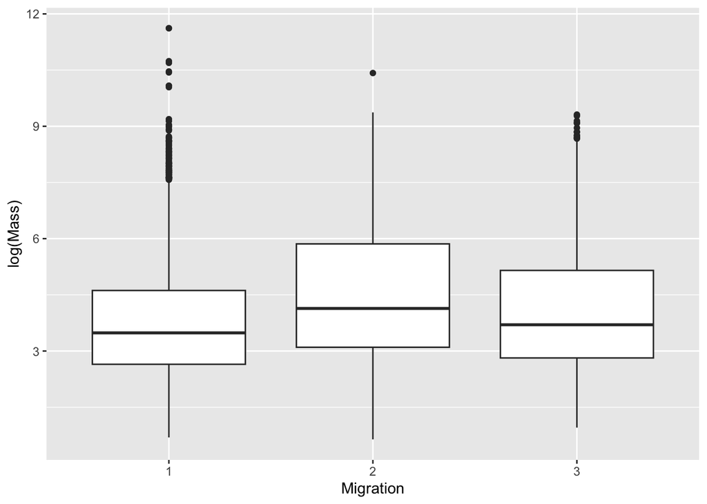

```r
d %>%
  ggplot(aes(x = Migration, y = log(Mass))) +
  geom_boxplot()
```

## Step 2

Both are significantly associated with log(Mass). (p-value < 0.05)

Both Migration2 and Migration3 differ significantly from Migration1. (very small p-values)

Migration1 is the reference level.

```r
summary(lm(log(Mass) ~ Trophic.Level, data=d))
```

```
##
## Call:
## lm(formula = log(Mass) ~ Trophic.Level, data = d)
##
## Residuals:
##     Min      1Q  Median      3Q     Max
## -3.4230 -1.1559 -0.3047  0.9004  7.5525
##
## Coefficients:
##                        Estimate Std. Error t value Pr(>|t|)
## (Intercept)             3.80916    0.01970 193.354  < 2e-16 ***
## Trophic.LevelHerbivore  0.25566    0.03410   7.498 6.96e-14 ***
## Trophic.LevelOmnivore   0.01410    0.04122   0.342    0.732
## Trophic.LevelScavenger  4.63107    0.34467  13.436  < 2e-16 ***
## ---
## Signif. codes:  0 '***' 0.001 '**' 0.01 '*' 0.05 '.' 0.1 ' ' 1
##
## Residual standard error: 1.539 on 10982 degrees of freedom
## Multiple R-squared:  0.02091,    Adjusted R-squared:  0.02064
## F-statistic: 78.18 on 3 and 10982 DF,  p-value: < 2.2e-16
```

```r
summary(lm(log(Mass) ~ Migration, data=d))
```

```
##
## Call:
## lm(formula = log(Mass) ~ Migration, data = d)
##
## Residuals:
##     Min      1Q  Median      3Q     Max
## -3.8924 -1.1769 -0.3088  0.9152  7.8427
##
## Coefficients:
##             Estimate Std. Error t value Pr(>|t|)
## (Intercept)  3.77457    0.01636 230.710  < 2e-16 ***
## Migration2   0.75971    0.04731  16.059  < 2e-16 ***
## Migration3   0.37647    0.05155   7.303 3.02e-13 ***
## ---
## Signif. codes:  0 '***' 0.001 '**' 0.01 '*' 0.05 '.' 0.1 ' ' 1
##
## Residual standard error: 1.535 on 10983 degrees of freedom
## Multiple R-squared:  0.02563,    Adjusted R-squared:  0.02546
## F-statistic: 144.5 on 2 and 10983 DF,  p-value: < 2.2e-16
```

All three categories are significantly different from each other.

```r
summary(lm(log(Mass) ~ relevel(d$Migration, ref = "2"), data = d))
```

```
##
## Call:
## lm(formula = log(Mass) ~ relevel(d$Migration, ref = "2"), data = d)
##
## Residuals:
##     Min      1Q  Median      3Q     Max
## -3.8924 -1.1769 -0.3088  0.9152  7.8427
##
## Coefficients:
##                                  Estimate Std. Error t value Pr(>|t|)
## (Intercept)                       4.53428    0.04439 102.149  < 2e-16 ***
## relevel(d$Migration, ref = "2")1 -0.75971    0.04731 -16.059  < 2e-16 ***
## relevel(d$Migration, ref = "2")3 -0.38324    0.06603  -5.804 6.67e-09 ***
## ---
## Signif. codes:  0 '***' 0.001 '**' 0.01 '*' 0.05 '.' 0.1 ' ' 1
##
## Residual standard error: 1.535 on 10983 degrees of freedom
## Multiple R-squared:  0.02563,    Adjusted R-squared:  0.02546
## F-statistic: 144.5 on 2 and 10983 DF,  p-value: < 2.2e-16
```

## Step 3

All migration groups differ significantly from one another.

```r
m <- aov(log(Mass) ~ Migration, data = d)
posthoc <- TukeyHSD(m, which = "Migration", ordered = TRUE, conf.level = 0.95)
posthoc
```

```
##   Tukey multiple comparisons of means
##     95% family-wise confidence level
##     factor levels have been ordered
##
## Fit: aov(formula = log(Mass) ~ Migration, data = d)
##
## $Migration
##          diff       lwr       upr p adj
## 3-1 0.3764693 0.2556282 0.4973105     0
## 2-1 0.7597067 0.6488157 0.8705977     0
## 2-3 0.3832374 0.2284536 0.5380211     0
```

## Step 4

```r
library(infer)

d <- d %>%
  mutate(logMass = log(Mass))

obs_f <- d %>%
  specify(logMass ~ Trophic.Level) %>%
  calculate(stat = "F")

# Null distribution
null_dist <- d %>%
  specify(logMass ~ Trophic.Level) %>%
  hypothesize(null = "independence") %>%
  generate(reps = 1000, type = "permute") %>%
  calculate(stat = "F")

# Empirical p-value
get_p_value(null_dist, obs_stat = obs_f, direction = "greater")
```

```
## # A tibble: 1 × 1
##   p_value
##     <dbl>
## 1       0
```

# Challenge 2

## Step 1

```r
relBeak <- lm(log(d$Beak.Length_Culmen)~log(d$Mass), data=d)
relTarsus <- lm(log(d$Tarsus.Length)~log(d$Mass), data=d)
d <- d %>%
  mutate(relBeak = relBeak$residuals,
         relTarsus = relTarsus$residuals)
```

## Step 2

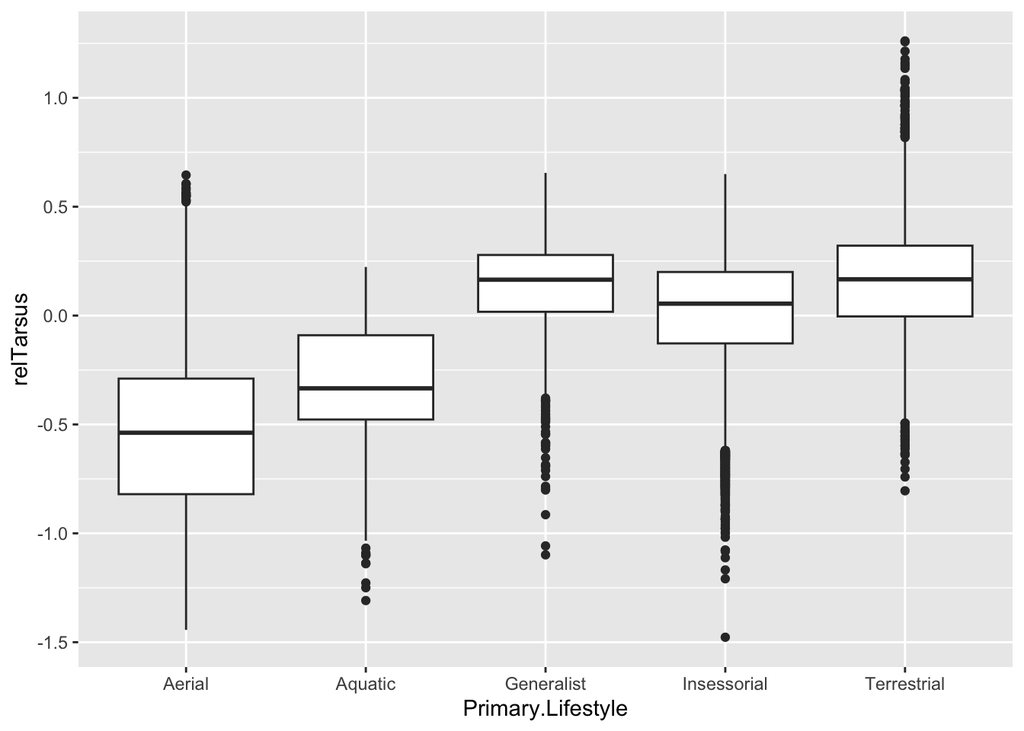

```r
ggplot(d, aes(x = Primary.Lifestyle, y = relTarsus)) +
  geom_boxplot()
```

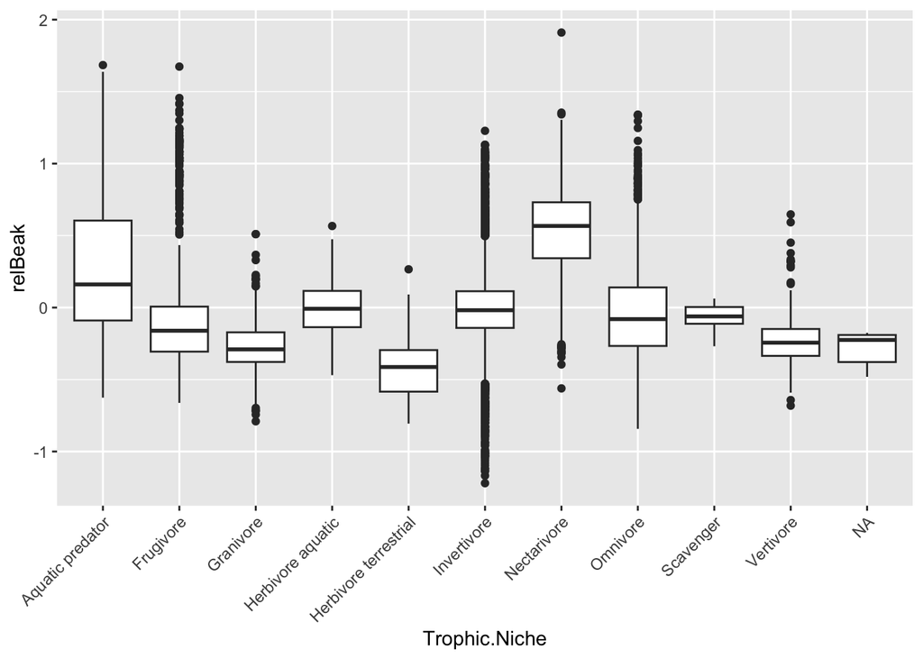

```r
ggplot(d, aes(x = Trophic.Niche, y = relBeak)) +
  geom_boxplot() +
  theme(axis.text.x = element_text(angle = 45, hjust = 1))
```

## Step 3

Migration is significantly associated with log(Range.Size).

Migration behavior explains approximately 8.7% of the variance in log-transformed geographic range size.

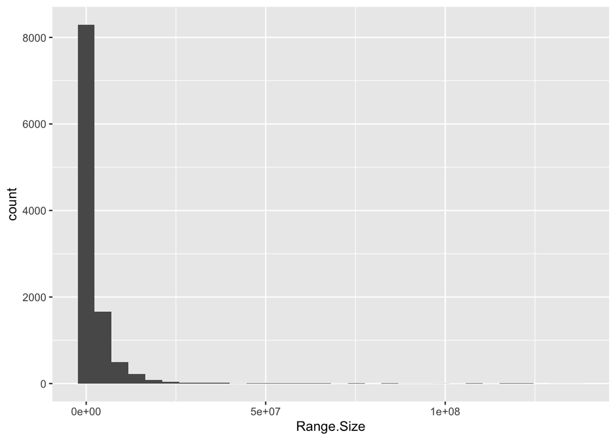

```r
d <- d %>%
  filter(!is.na(Migration))

# Right-skewed
ggplot(d, aes(x = Range.Size)) +
  geom_histogram(bins = 30)
```

```r
# It needs to be log-transformed
d <- d %>%
  mutate(logRS = log(Range.Size))

m <- lm(logRS ~ Migration, data = d)
summary(m)
```

```
##
## Call:
## lm(formula = logRS ~ Migration, data = d)
##
## Residuals:
##      Min       1Q   Median       3Q      Max
## -14.5710  -1.4521   0.4357   1.9763   5.9271
##
## Coefficients:
##             Estimate Std. Error t value Pr(>|t|)
## (Intercept) 12.03381    0.02974  404.62   <2e-16 ***
## Migration2   1.78469    0.08606   20.74   <2e-16 ***
## Migration3   2.51702    0.09380   26.83   <2e-16 ***
## ---
## Signif. codes:  0 '***' 0.001 '**' 0.01 '*' 0.05 '.' 0.1 ' ' 1
##
## Residual standard error: 2.785 on 10934 degrees of freedom
##   (49 observations deleted due to missingness)
## Multiple R-squared:  0.0869, Adjusted R-squared:  0.08674
## F-statistic: 520.3 on 2 and 10934 DF,  p-value: < 2.2e-16
```

Both Migration2 and Migration3 are significantly different from the reference (Migration1).

All three migration categories are significantly different from each other. (p-value < 0)

```r
m2 <- lm(logRS ~ relevel(d$Migration, ref = "2"), data = d)
summary(m2)
```

```
##
## Call:
## lm(formula = logRS ~ relevel(d$Migration, ref = "2"), data = d)
##
## Residuals:
##      Min       1Q   Median       3Q      Max
## -14.5710  -1.4521   0.4357   1.9763   5.9271
##
## Coefficients:
##                                  Estimate Std. Error t value Pr(>|t|)
## (Intercept)                      13.81850    0.08076 171.099  < 2e-16 ***
## relevel(d$Migration, ref = "2")1 -1.78469    0.08606 -20.737  < 2e-16 ***
## relevel(d$Migration, ref = "2")3  0.73233    0.12015   6.095 1.13e-09 ***
## ---
## Signif. codes:  0 '***' 0.001 '**' 0.01 '*' 0.05 '.' 0.1 ' ' 1
##
## Residual standard error: 2.785 on 10934 degrees of freedom
##   (49 observations deleted due to missingness)
## Multiple R-squared:  0.0869, Adjusted R-squared:  0.08674
## F-statistic: 520.3 on 2 and 10934 DF,  p-value: < 2.2e-16
```

```r
m3 <- aov(log(Mass) ~ Migration, data = d)
posthoc <- TukeyHSD(m3, which = "Migration", ordered = TRUE, conf.level = 0.95)
posthoc
```

```
##   Tukey multiple comparisons of means
##     95% family-wise confidence level
##     factor levels have been ordered
##
## Fit: aov(formula = log(Mass) ~ Migration, data = d)
##
## $Migration
##          diff       lwr       upr p adj
## 3-1 0.3764693 0.2556282 0.4973105     0
## 2-1 0.7597067 0.6488157 0.8705977     0
## 2-3 0.3832374 0.2284536 0.5380211     0
```

## Step 4

```r
d_p <- d %>%
  filter(Order1 == "Passeriformes")
```

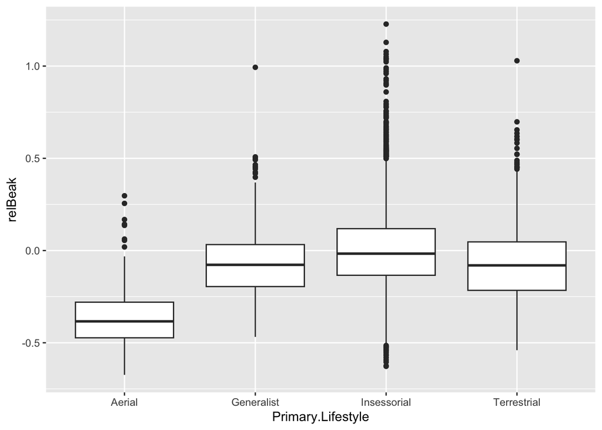

```r
ggplot(d_p, aes(x = Primary.Lifestyle, y = relBeak)) +
  geom_boxplot()
```

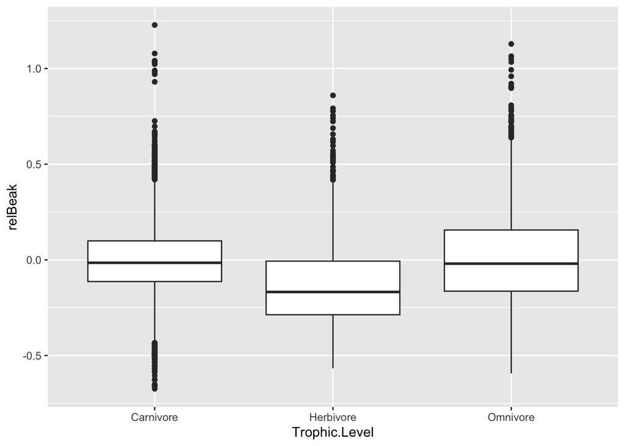

```r
ggplot(d_p, aes(x = Trophic.Level, y = relBeak)) +
  geom_boxplot()
```

Primary.Lifestyle is strongly associated with relative beak length.

And there is a significant difference between groups.

```r
m3 <- lm(relBeak ~ Primary.Lifestyle, data = d_p)
summary(m3)
```

```
##
## Call:
## lm(formula = relBeak ~ Primary.Lifestyle, data = d_p)
##
## Residuals:
##      Min       1Q   Median       3Q      Max
## -0.63098 -0.13765 -0.01698  0.11201  1.22436
##
## Coefficients:
##                              Estimate Std. Error t value Pr(>|t|)
## (Intercept)                  -0.34896    0.02165  -16.12   <2e-16 ***
## Primary.LifestyleGeneralist   0.27858    0.02312   12.05   <2e-16 ***
## Primary.LifestyleInsessorial  0.35225    0.02188   16.10   <2e-16 ***
## Primary.LifestyleTerrestrial  0.27838    0.02255   12.35   <2e-16 ***
## ---
## Signif. codes:  0 '***' 0.001 '**' 0.01 '*' 0.05 '.' 0.1 ' ' 1
##
## Residual standard error: 0.2154 on 6602 degrees of freedom
## Multiple R-squared:  0.05534,    Adjusted R-squared:  0.05492
## F-statistic: 128.9 on 3 and 6602 DF,  p-value: < 2.2e-16
```

```r
anova(m3)
```

```
## Analysis of Variance Table
##
## Response: relBeak
##                     Df  Sum Sq Mean Sq F value    Pr(>F)
## Primary.Lifestyle    3  17.943  5.9810  128.93 < 2.2e-16 ***
## Residuals         6602 306.262  0.0464
## ---
## Signif. codes:  0 '***' 0.001 '**' 0.01 '*' 0.05 '.' 0.1 ' ' 1
```

Trophic.Level is strongly associated with relative beak length.

And there is a significant difference between groups.

```r
m4 <- lm(relBeak ~ Trophic.Level, data = d_p)
summary(m4)
```

```
##
## Call:
## lm(formula = relBeak ~ Trophic.Level, data = d_p)
##
## Residuals:
##      Min       1Q   Median       3Q      Max
## -0.67028 -0.13672 -0.02056  0.11134  1.23126
##
## Coefficients:
##                         Estimate Std. Error t value Pr(>|t|)
## (Intercept)            -0.003606   0.003495  -1.032  0.30213
## Trophic.LevelHerbivore -0.118573   0.006940 -17.084  < 2e-16 ***
## Trophic.LevelOmnivore   0.017822   0.006596   2.702  0.00691 **
## ---
## Signif. codes:  0 '***' 0.001 '**' 0.01 '*' 0.05 '.' 0.1 ' ' 1
##
## Residual standard error: 0.216 on 6603 degrees of freedom
## Multiple R-squared:  0.05015,    Adjusted R-squared:  0.04986
## F-statistic: 174.3 on 2 and 6603 DF,  p-value: < 2.2e-16
```

```r
anova(m4)
```

```
## Analysis of Variance Table
##
## Response: relBeak
##                 Df  Sum Sq Mean Sq F value    Pr(>F)
## Trophic.Level    2  16.258  8.1290   174.3 < 2.2e-16 ***
## Residuals     6603 307.947  0.0466
## ---
## Signif. codes:  0 '***' 0.001 '**' 0.01 '*' 0.05 '.' 0.1 ' ' 1
```

```r
unique(d_p$Primary.Lifestyle)
```

```
## [1] "Insessorial" "Generalist"  "Terrestrial" "Aerial"
```

```r
unique(d_p$Trophic.Level)
```

```
## [1] "Carnivore" "Omnivore"  "Herbivore"
```

## Step 5

Two-way ANOVA showed that both Primary.Lifestyle and Trophic.Level are significantly associated with relative beak length.

Primary.Lifestyle: All three show significantly longer relative beaks than Aerial species.

Trophic.Level: Herbivore clearly differ from carnivore, while omnivore is similar.

```r
m5 <- lm(relBeak ~ Primary.Lifestyle + Trophic.Level, data = d_p)
summary(m5)
```

```
##
## Call:
## lm(formula = relBeak ~ Primary.Lifestyle + Trophic.Level, data = d_p)
##
## Residuals:
##      Min       1Q   Median       3Q      Max
## -0.65325 -0.13306 -0.02275  0.10260  1.20210
##
## Coefficients:
##                               Estimate Std. Error t value Pr(>|t|)
## (Intercept)                  -0.348963   0.021018 -16.603   <2e-16 ***
## Primary.LifestyleGeneralist   0.300866   0.022636  13.292   <2e-16 ***
## Primary.LifestyleInsessorial  0.374519   0.021354  17.539   <2e-16 ***
## Primary.LifestyleTerrestrial  0.301215   0.021996  13.694   <2e-16 ***
## Trophic.LevelHerbivore       -0.126163   0.006748 -18.697   <2e-16 ***
## Trophic.LevelOmnivore         0.012133   0.006442   1.884   0.0597 .
## ---
## Signif. codes:  0 '***' 0.001 '**' 0.01 '*' 0.05 '.' 0.1 ' ' 1
##
## Residual standard error: 0.2091 on 6600 degrees of freedom
## Multiple R-squared:  0.1097, Adjusted R-squared:  0.109
## F-statistic: 162.6 on 5 and 6600 DF,  p-value: < 2.2e-16
```

```r
anova(m5)
```

```
## Analysis of Variance Table
##
## Response: relBeak
##                     Df  Sum Sq Mean Sq F value    Pr(>F)
## Primary.Lifestyle    3  17.943  5.9810  136.75 < 2.2e-16 ***
## Trophic.Level        2  17.607  8.8037  201.29 < 2.2e-16 ***
## Residuals         6600 288.655  0.0437
## ---
## Signif. codes:  0 '***' 0.001 '**' 0.01 '*' 0.05 '.' 0.1 ' ' 1
```

## Step 6

Relative beak length is significantly influenced by both primary lifestyle and trophic level, and their interaction indicates that the effect of one depends on the other.

```r
m6 <- lm(relBeak ~ Primary.Lifestyle + Trophic.Level + Primary.Lifestyle:Trophic.Level, data = d_p)
summary(m6)
```

```
##
## Call:
## lm(formula = relBeak ~ Primary.Lifestyle + Trophic.Level + Primary.Lifestyle:Trophic.Level,
##     data = d_p)
##
## Residuals:
##      Min       1Q   Median       3Q      Max
## -0.64584 -0.12855 -0.02082  0.10078  1.21960
##
## Coefficients: (2 not defined because of singularities)
##                                                     Estimate Std. Error t value
## (Intercept)                                         -0.34896    0.02071 -16.846
## Primary.LifestyleGeneralist                          0.32984    0.02371  13.910
## Primary.LifestyleInsessorial                         0.35702    0.02109  16.928
## Primary.LifestyleTerrestrial                         0.35628    0.02215  16.088
## Trophic.LevelHerbivore                              -0.27497    0.01558 -17.645
## Trophic.LevelOmnivore                               -0.11080    0.01546  -7.166
## Primary.LifestyleGeneralist:Trophic.LevelHerbivore   0.04973    0.02579   1.929
## Primary.LifestyleInsessorial:Trophic.LevelHerbivore  0.20150    0.01746  11.540
## Primary.LifestyleTerrestrial:Trophic.LevelHerbivore       NA         NA      NA
## Primary.LifestyleGeneralist:Trophic.LevelOmnivore    0.09844    0.02348   4.192
## Primary.LifestyleInsessorial:Trophic.LevelOmnivore   0.15539    0.01722   9.022
## Primary.LifestyleTerrestrial:Trophic.LevelOmnivore        NA         NA      NA
##                                                     Pr(>|t|)
## (Intercept)                                          < 2e-16 ***
## Primary.LifestyleGeneralist                          < 2e-16 ***
## Primary.LifestyleInsessorial                         < 2e-16 ***
## Primary.LifestyleTerrestrial                         < 2e-16 ***
## Trophic.LevelHerbivore                               < 2e-16 ***
## Trophic.LevelOmnivore                               8.53e-13 ***
## Primary.LifestyleGeneralist:Trophic.LevelHerbivore    0.0538 .
## Primary.LifestyleInsessorial:Trophic.LevelHerbivore  < 2e-16 ***
## Primary.LifestyleTerrestrial:Trophic.LevelHerbivore       NA
## Primary.LifestyleGeneralist:Trophic.LevelOmnivore   2.81e-05 ***
## Primary.LifestyleInsessorial:Trophic.LevelOmnivore   < 2e-16 ***
## Primary.LifestyleTerrestrial:Trophic.LevelOmnivore        NA
## ---
## Signif. codes:  0 '***' 0.001 '**' 0.01 '*' 0.05 '.' 0.1 ' ' 1
##
## Residual standard error: 0.2061 on 6596 degrees of freedom
## Multiple R-squared:  0.1357, Adjusted R-squared:  0.1345
## F-statistic: 115.1 on 9 and 6596 DF,  p-value: < 2.2e-16
```

```r
anova(m6)
```

```
## Analysis of Variance Table
##
## Response: relBeak
##                                   Df  Sum Sq Mean Sq F value    Pr(>F)
## Primary.Lifestyle                  3  17.943  5.9810 140.791 < 2.2e-16 ***
## Trophic.Level                      2  17.607  8.8037 207.235 < 2.2e-16 ***
## Primary.Lifestyle:Trophic.Level    4   8.444  2.1110  49.693 < 2.2e-16 ***
## Residuals                       6596 280.210  0.0425
## ---
## Signif. codes:  0 '***' 0.001 '**' 0.01 '*' 0.05 '.' 0.1 ' ' 1
```

## Step 7

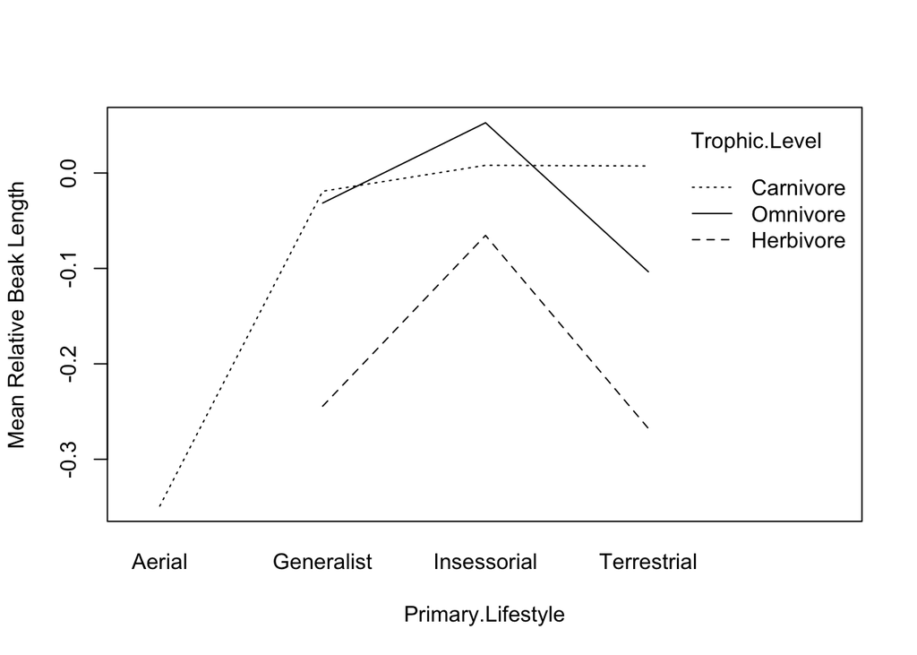

```r
interaction.plot(x.factor = d_p$Primary.Lifestyle, xlab = "Primary.Lifestyle",
                 trace.factor = d_p$Trophic.Level, trace.label = "Trophic.Level",
                 response = d_p$relBeak, fun = base::mean, ylab = "Mean Relative Beak Length")
```

## Step 8

Less than 2. (the assumption may not be violated)

```r
# Trophic.Level
d_p %>%
  group_by(Trophic.Level) %>%
  summarise(n = n(), sd_relBeak = sd(relBeak)) %>%
  summarise(ratio = max(sd_relBeak) / min(sd_relBeak))
```

```
## # A tibble: 1 × 1
##   ratio
##   <dbl>
## 1  1.34
```

```r
# Primary.Lifestyle
d_p %>%
  group_by(Primary.Lifestyle) %>%
  summarise(n = n(), sd_relBeak = sd(relBeak)) %>%
  summarise(ratio = max(sd_relBeak) / min(sd_relBeak))
```

```
## # A tibble: 1 × 1
##   ratio
##   <dbl>
## 1  1.24
```

Residuals were approximately normally distributed across most groups.

Minor deviations were observed, but overall the normality assumption appears reasonably met.

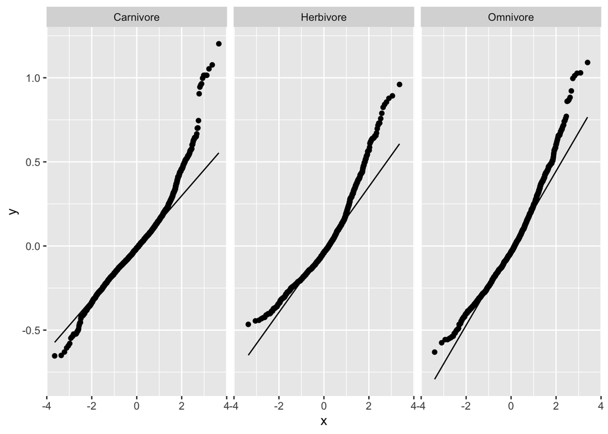

```r
mod <- lm(relBeak ~ Trophic.Level + Primary.Lifestyle, data = d_p)
d_p$resid <- residuals(mod)

library(ggplot2)

# Trophic.Level
ggplot(d_p, aes(sample = resid)) +
  stat_qq() +
  stat_qq_line() +
  facet_wrap(~ Trophic.Level)
```

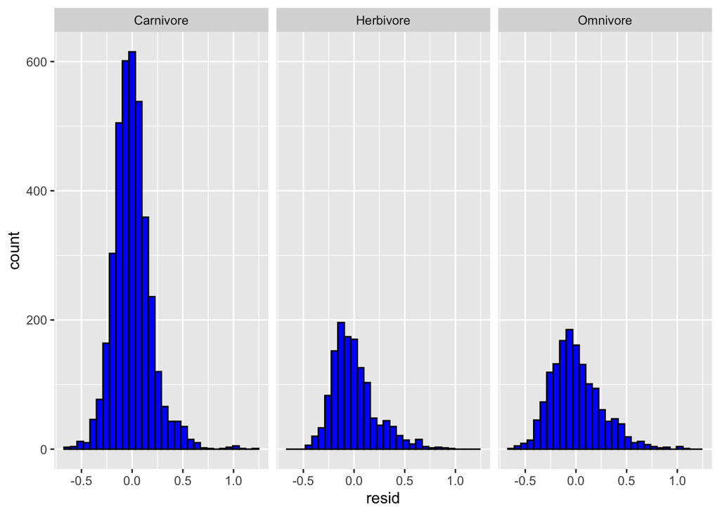

```r
ggplot(d_p, aes(x = resid)) +
  geom_histogram(bins = 30, fill = "blue", color = "black") +
  facet_wrap(~ Trophic.Level)
```

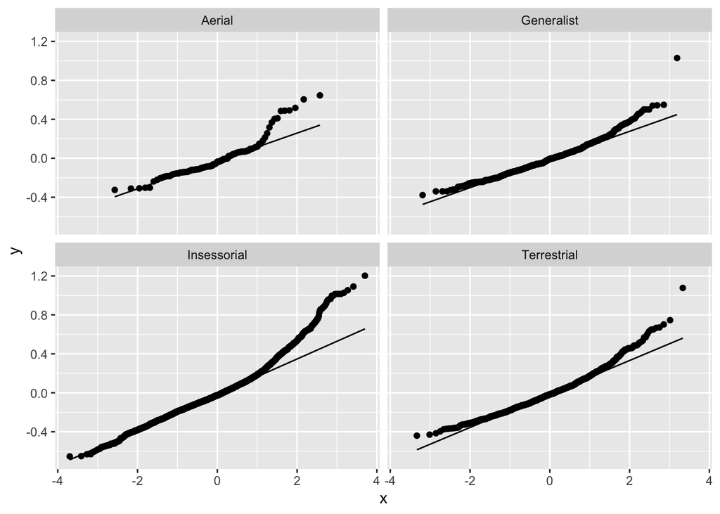

```r
# Primary.Lifestyle
ggplot(d_p, aes(sample = resid)) +
  stat_qq() +
  stat_qq_line() +
  facet_wrap(~ Primary.Lifestyle)
```

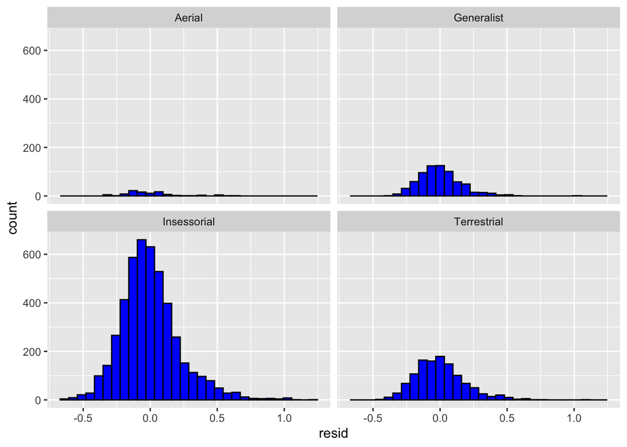

```r
ggplot(d_p, aes(x = resid)) +
  geom_histogram(bins = 30, fill = "blue", color = "black") +
  facet_wrap(~ Primary.Lifestyle)
```